# 01_circle_to_wave

## 01_circle_to_wave

#### Question

1. We began by defining the trigonometric ratios of **right triangles**. We saw it was beneficial to move to unit-**circle** definitions to allow for any angle (not just acute angles of right triangles). Now, we will see that when we plot trigonometric functions, we get **[waves](https://en.wikipedia.org/wiki/Sine_and_cosine#Graph_of_a_function_and_its_elementary_properties)** (and other [periodic](https://en.wikipedia.org/wiki/Periodic_function) functions).

   In [Desmos](https://www.desmos.com/calculator), you can store a list of angles (in radians) with the following expression: `T=[0.478, 0.684, 1.33, 1.906, 2.137, 3.403, 3.725, 4.481, 5.167, 5.538]`

   $$T=[0.478, 0.684, 1.33, 1.906, 2.137, 3.403, 3.725, 4.481, 5.167, 5.538]$$

   From that list of angles, you can plot the corresponding points on the unit circle with the following expression: `(cos(T),sin(T))`. Find the corresponding graph.

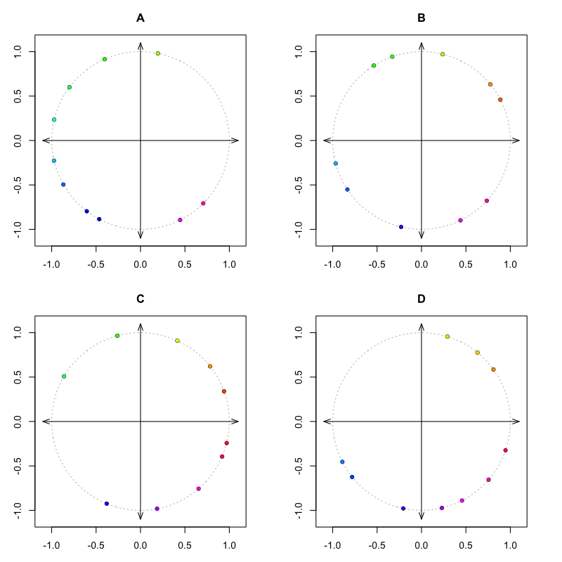

   - Plot matches the given list of angles.

   Now, in Desmos, you can type `(T,sin(T))` to get the points along the sine wave. Find the corresponding graph.

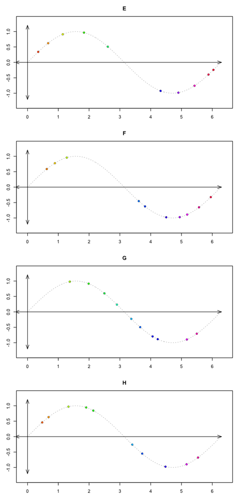

   - Plot matches the given list of angles.

   Lastly, in Desmos, you can type `(T,cos(T))` to get the points along the cosine wave. Find the corresponding graph.

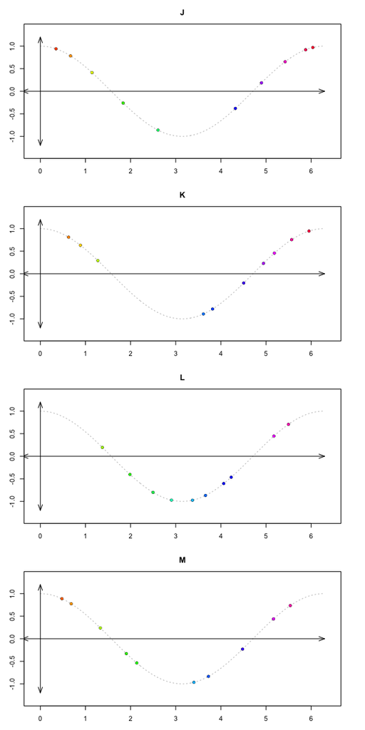

#### Question

2. We began by defining the trigonometric ratios of **right triangles**. We saw it was beneficial to move to unit-**circle** definitions to allow for any angle (not just acute angles of right triangles). Now, we will see that when we plot trigonometric functions, we get **[waves](https://en.wikipedia.org/wiki/Sine_and_cosine#Graph_of_a_function_and_its_elementary_properties)** (and other [periodic](https://en.wikipedia.org/wiki/Periodic_function) functions).

   In [Desmos](https://www.desmos.com/calculator), you can store a list of angles (in radians) with the following expression: `T=[0.436, 0.66, 1.058, 1.304, 2.332, 4.179, 4.899, 5.083, 5.453, 5.751]`

   $$T=[0.436, 0.66, 1.058, 1.304, 2.332, 4.179, 4.899, 5.083, 5.453, 5.751]$$

   From that list of angles, you can plot the corresponding points on the unit circle with the following expression: `(cos(T),sin(T))`. Find the corresponding graph.

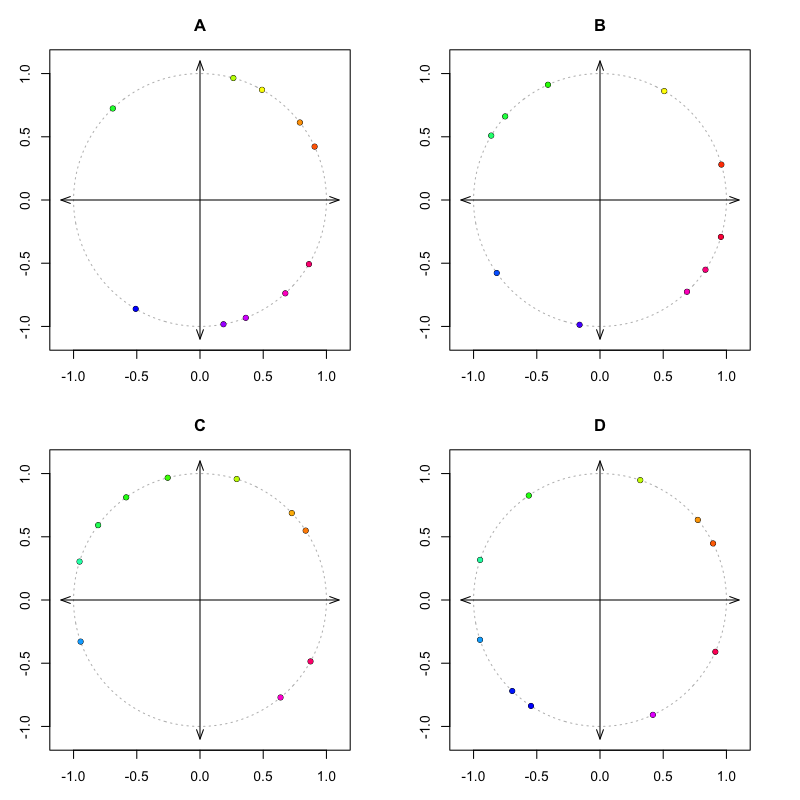

   - Plot matches the given list of angles.

   Now, in Desmos, you can type `(T,sin(T))` to get the points along the sine wave. Find the corresponding graph.

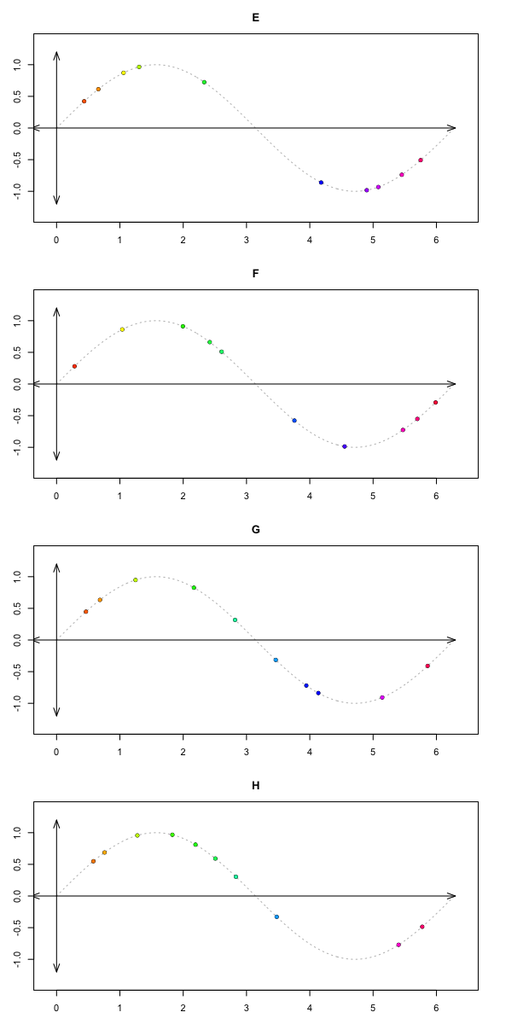

   - Plot matches the given list of angles.

   Lastly, in Desmos, you can type `(T,cos(T))` to get the points along the cosine wave. Find the corresponding graph.

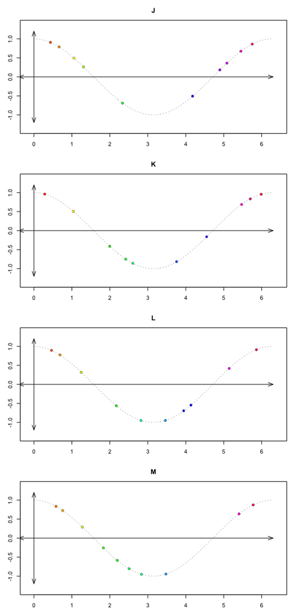

#### Question

3. We began by defining the trigonometric ratios of **right triangles**. We saw it was beneficial to move to unit-**circle** definitions to allow for any angle (not just acute angles of right triangles). Now, we will see that when we plot trigonometric functions, we get **[waves](https://en.wikipedia.org/wiki/Sine_and_cosine#Graph_of_a_function_and_its_elementary_properties)** (and other [periodic](https://en.wikipedia.org/wiki/Periodic_function) functions).

   In [Desmos](https://www.desmos.com/calculator), you can store a list of angles (in radians) with the following expression: `T=[0.372, 1.183, 1.351, 1.803, 2.389, 3.869, 4.12, 4.939, 5.127, 5.651]`

   $$T=[0.372, 1.183, 1.351, 1.803, 2.389, 3.869, 4.12, 4.939, 5.127, 5.651]$$

   From that list of angles, you can plot the corresponding points on the unit circle with the following expression: `(cos(T),sin(T))`. Find the corresponding graph.

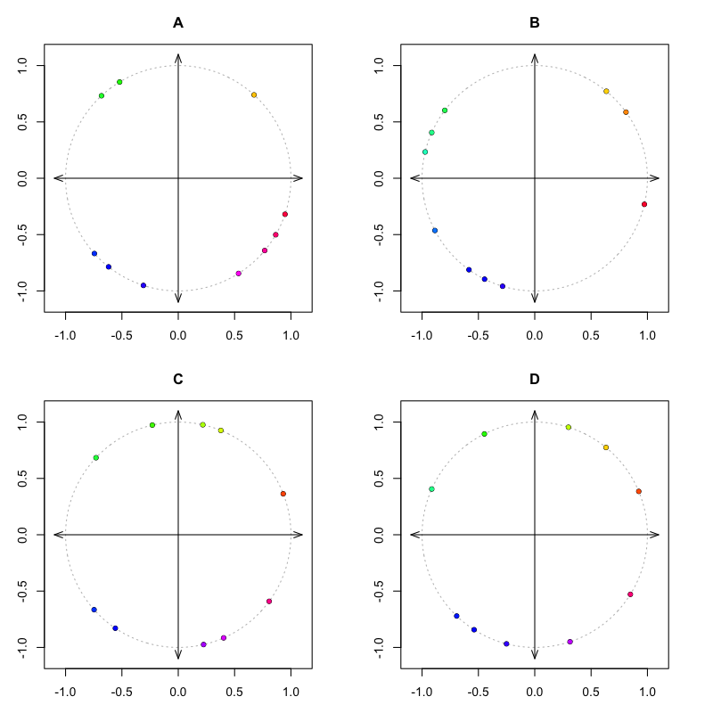

   - Plot matches the given list of angles.

   Now, in Desmos, you can type `(T,sin(T))` to get the points along the sine wave. Find the corresponding graph.

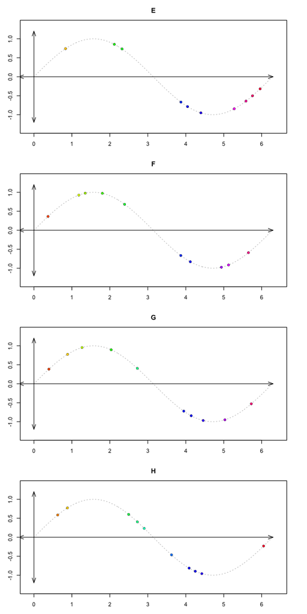

   - Plot matches the given list of angles.

   Lastly, in Desmos, you can type `(T,cos(T))` to get the points along the cosine wave. Find the corresponding graph.

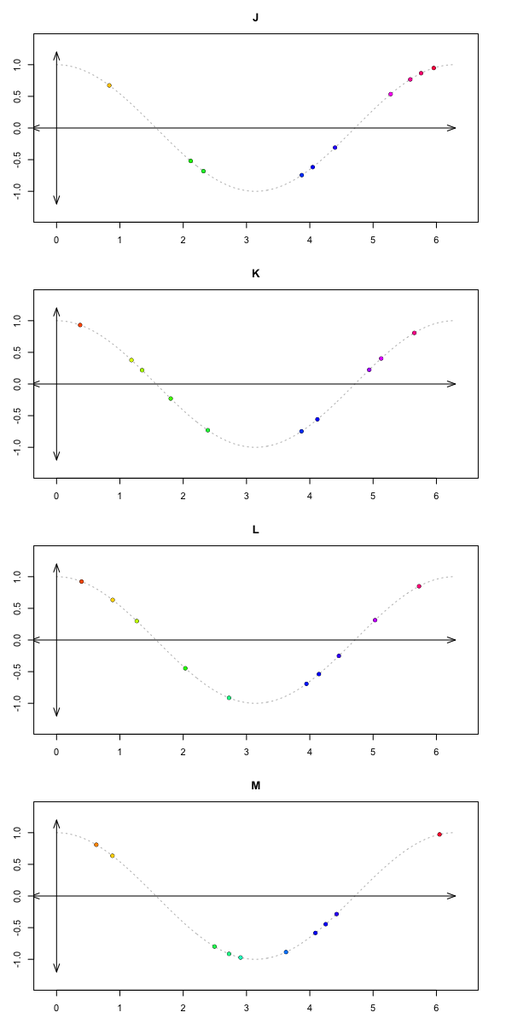

#### Question

4. We began by defining the trigonometric ratios of **right triangles**. We saw it was beneficial to move to unit-**circle** definitions to allow for any angle (not just acute angles of right triangles). Now, we will see that when we plot trigonometric functions, we get **[waves](https://en.wikipedia.org/wiki/Sine_and_cosine#Graph_of_a_function_and_its_elementary_properties)** (and other [periodic](https://en.wikipedia.org/wiki/Periodic_function) functions).

   In [Desmos](https://www.desmos.com/calculator), you can store a list of angles (in radians) with the following expression: `T=[0.284, 0.73, 0.911, 1.215, 1.873, 2.721, 4.331, 5.149, 5.679, 5.837]`

   $$T=[0.284, 0.73, 0.911, 1.215, 1.873, 2.721, 4.331, 5.149, 5.679, 5.837]$$

   From that list of angles, you can plot the corresponding points on the unit circle with the following expression: `(cos(T),sin(T))`. Find the corresponding graph.

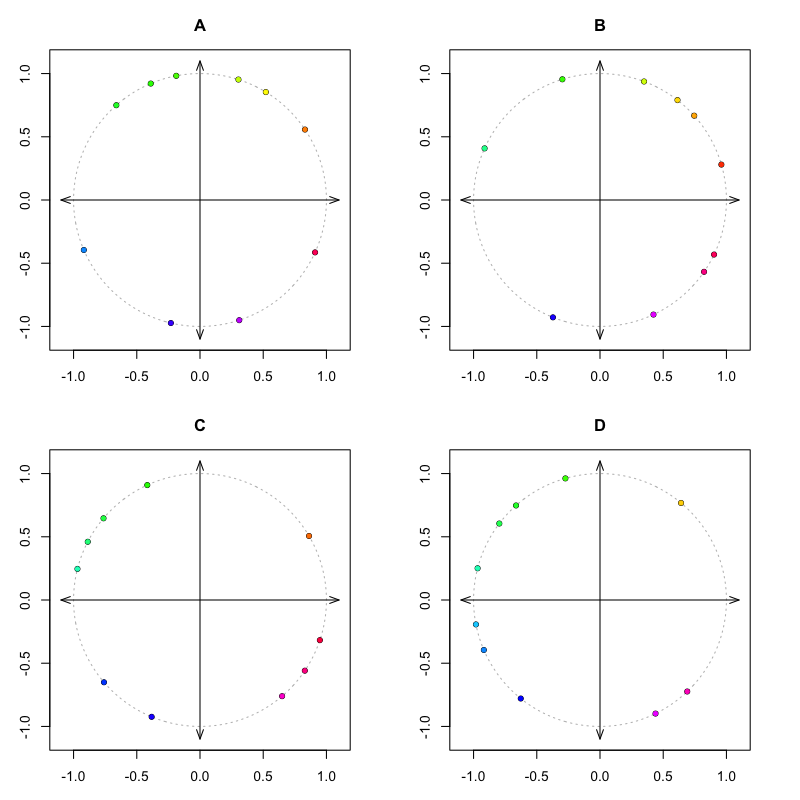

   - Plot matches the given list of angles.

   Now, in Desmos, you can type `(T,sin(T))` to get the points along the sine wave. Find the corresponding graph.

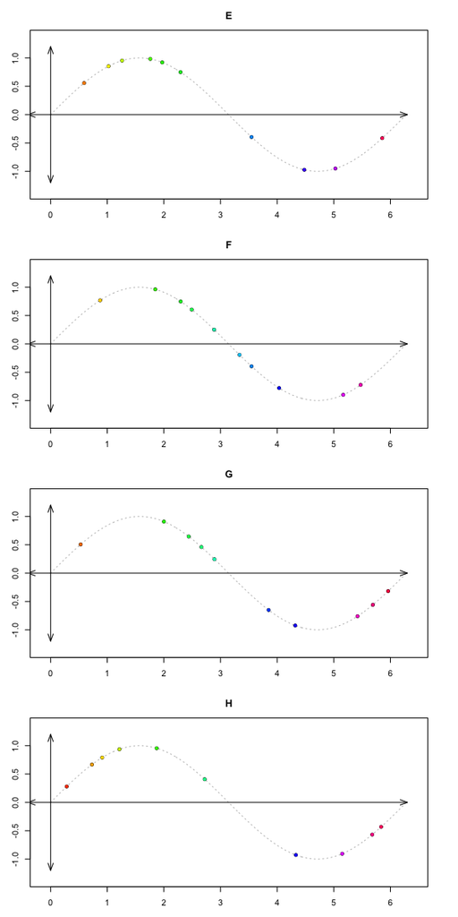

   - Plot matches the given list of angles.

   Lastly, in Desmos, you can type `(T,cos(T))` to get the points along the cosine wave. Find the corresponding graph.

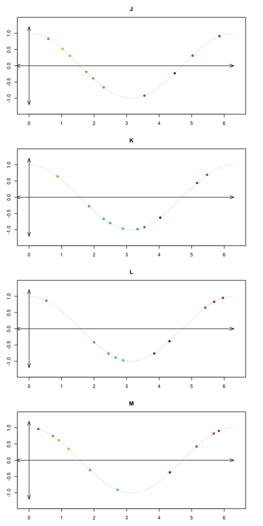

#### Question

5. We began by defining the trigonometric ratios of **right triangles**. We saw it was beneficial to move to unit-**circle** definitions to allow for any angle (not just acute angles of right triangles). Now, we will see that when we plot trigonometric functions, we get **[waves](https://en.wikipedia.org/wiki/Sine_and_cosine#Graph_of_a_function_and_its_elementary_properties)** (and other [periodic](https://en.wikipedia.org/wiki/Periodic_function) functions).

   In [Desmos](https://www.desmos.com/calculator), you can store a list of angles (in radians) with the following expression: `T=[0.227, 0.47, 0.684, 1.29, 2.652, 3.332, 3.823, 4.109, 5.022, 5.613]`

   $$T=[0.227, 0.47, 0.684, 1.29, 2.652, 3.332, 3.823, 4.109, 5.022, 5.613]$$

   From that list of angles, you can plot the corresponding points on the unit circle with the following expression: `(cos(T),sin(T))`. Find the corresponding graph.

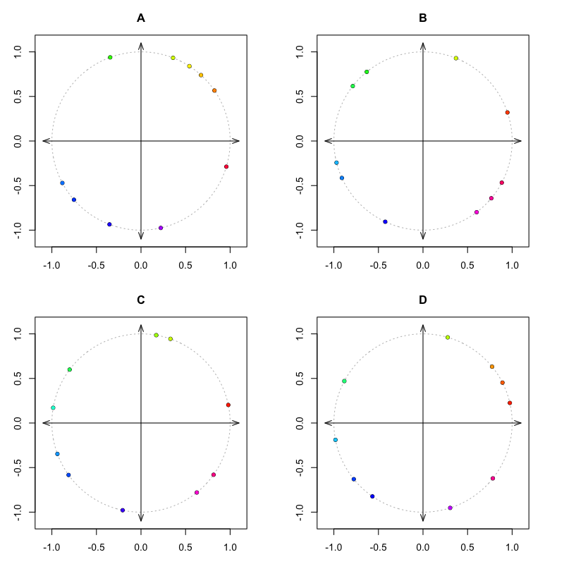

   - Plot matches the given list of angles.

   Now, in Desmos, you can type `(T,sin(T))` to get the points along the sine wave. Find the corresponding graph.

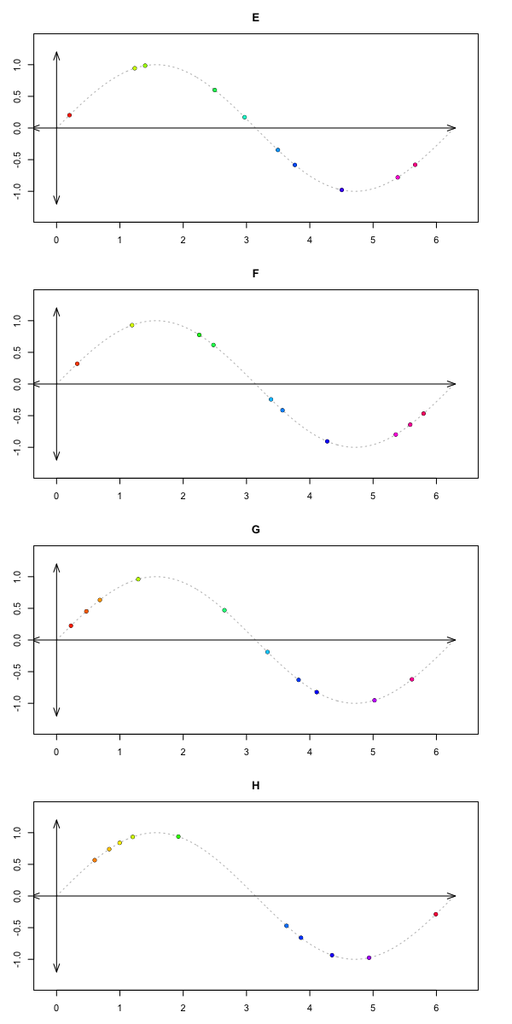

   - Plot matches the given list of angles.

   Lastly, in Desmos, you can type `(T,cos(T))` to get the points along the cosine wave. Find the corresponding graph.

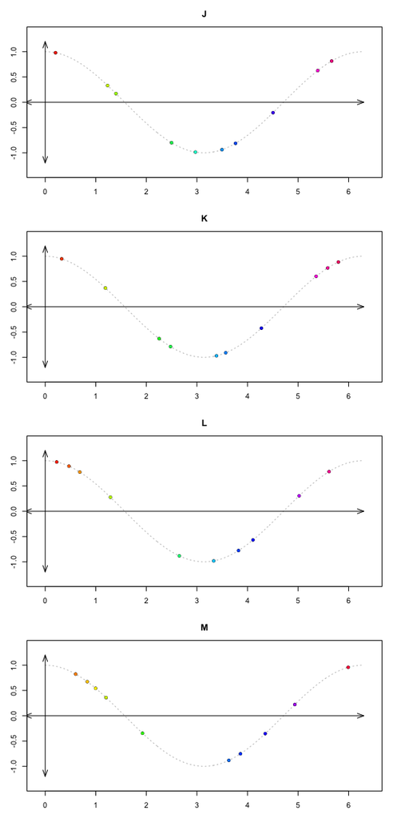

#### Question

6. We began by defining the trigonometric ratios of **right triangles**. We saw it was beneficial to move to unit-**circle** definitions to allow for any angle (not just acute angles of right triangles). Now, we will see that when we plot trigonometric functions, we get **[waves](https://en.wikipedia.org/wiki/Sine_and_cosine#Graph_of_a_function_and_its_elementary_properties)** (and other [periodic](https://en.wikipedia.org/wiki/Periodic_function) functions).

   In [Desmos](https://www.desmos.com/calculator), you can store a list of angles (in radians) with the following expression: `T=[0.358, 1.124, 1.332, 2.735, 2.96, 3.613, 4.431, 5.154, 5.322, 5.643]`

   $$T=[0.358, 1.124, 1.332, 2.735, 2.96, 3.613, 4.431, 5.154, 5.322, 5.643]$$

   From that list of angles, you can plot the corresponding points on the unit circle with the following expression: `(cos(T),sin(T))`. Find the corresponding graph.

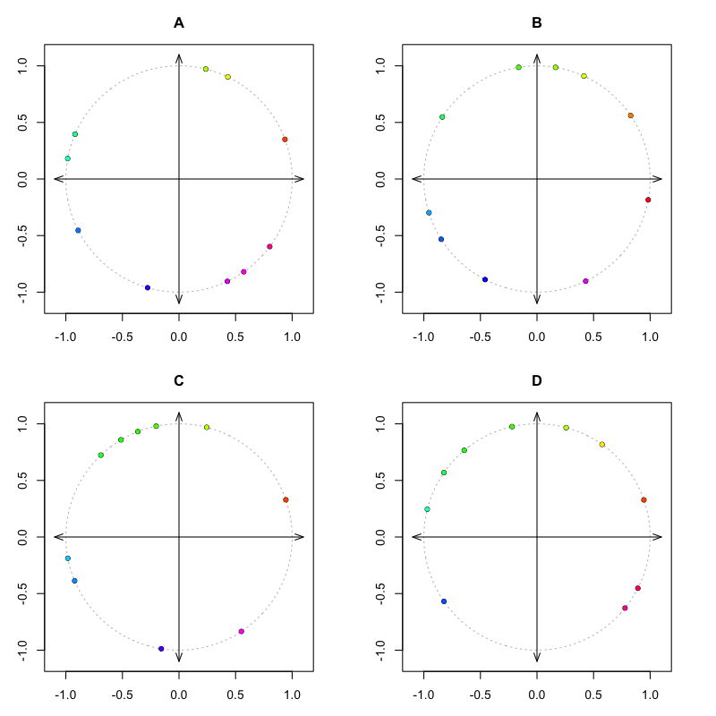

   - Plot matches the given list of angles.

   Now, in Desmos, you can type `(T,sin(T))` to get the points along the sine wave. Find the corresponding graph.

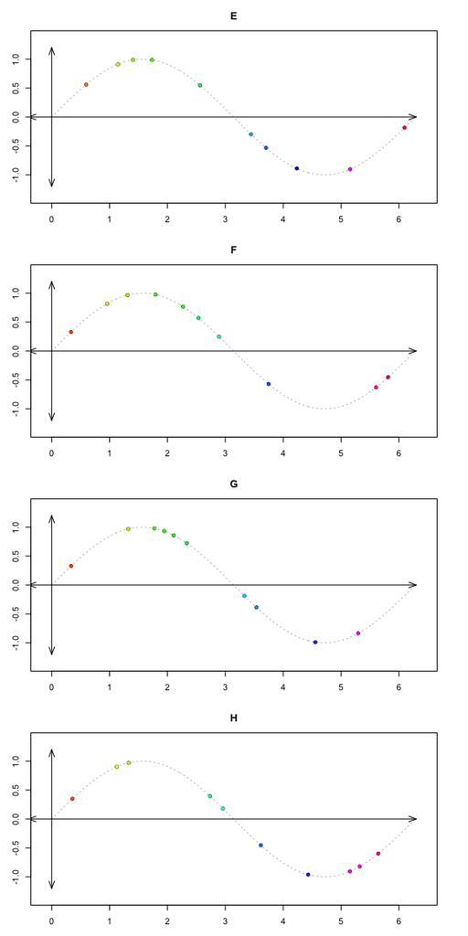

   - Plot matches the given list of angles.

   Lastly, in Desmos, you can type `(T,cos(T))` to get the points along the cosine wave. Find the corresponding graph.

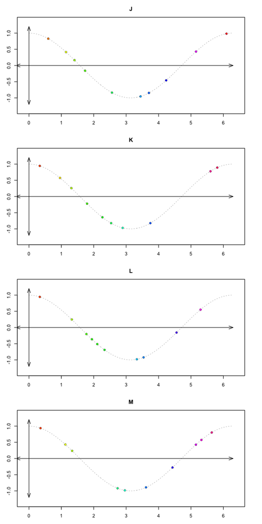

#### Question

7. We began by defining the trigonometric ratios of **right triangles**. We saw it was beneficial to move to unit-**circle** definitions to allow for any angle (not just acute angles of right triangles). Now, we will see that when we plot trigonometric functions, we get **[waves](https://en.wikipedia.org/wiki/Sine_and_cosine#Graph_of_a_function_and_its_elementary_properties)** (and other [periodic](https://en.wikipedia.org/wiki/Periodic_function) functions).

   In [Desmos](https://www.desmos.com/calculator), you can store a list of angles (in radians) with the following expression: `T=[0.166, 2.382, 2.641, 3.49, 3.853, 4.126, 4.308, 4.885, 5.51, 6.066]`

   $$T=[0.166, 2.382, 2.641, 3.49, 3.853, 4.126, 4.308, 4.885, 5.51, 6.066]$$

   From that list of angles, you can plot the corresponding points on the unit circle with the following expression: `(cos(T),sin(T))`. Find the corresponding graph.

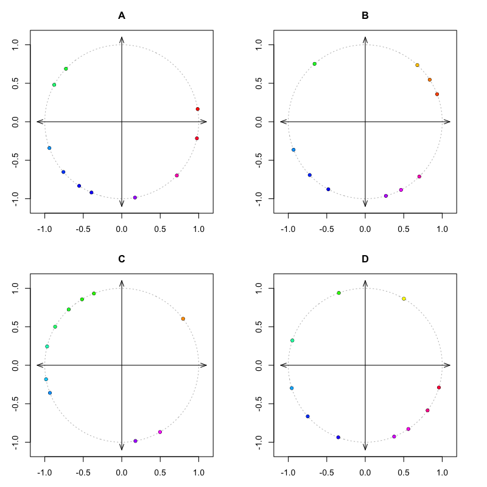

   - Plot matches the given list of angles.

   Now, in Desmos, you can type `(T,sin(T))` to get the points along the sine wave. Find the corresponding graph.

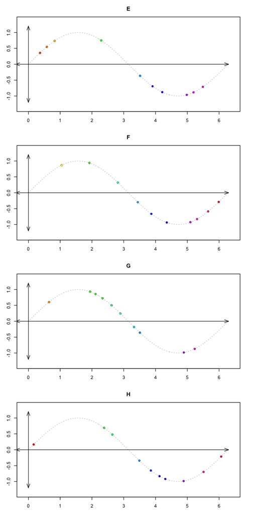

   - Plot matches the given list of angles.

   Lastly, in Desmos, you can type `(T,cos(T))` to get the points along the cosine wave. Find the corresponding graph.

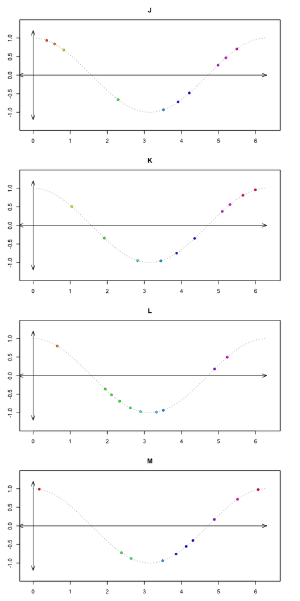

#### Question

8. We began by defining the trigonometric ratios of **right triangles**. We saw it was beneficial to move to unit-**circle** definitions to allow for any angle (not just acute angles of right triangles). Now, we will see that when we plot trigonometric functions, we get **[waves](https://en.wikipedia.org/wiki/Sine_and_cosine#Graph_of_a_function_and_its_elementary_properties)** (and other [periodic](https://en.wikipedia.org/wiki/Periodic_function) functions).

   In [Desmos](https://www.desmos.com/calculator), you can store a list of angles (in radians) with the following expression: `T=[0.552, 1.3, 1.88, 2.371, 3.773, 4.006, 4.164, 5.105, 5.606, 5.841]`

   $$T=[0.552, 1.3, 1.88, 2.371, 3.773, 4.006, 4.164, 5.105, 5.606, 5.841]$$

   From that list of angles, you can plot the corresponding points on the unit circle with the following expression: `(cos(T),sin(T))`. Find the corresponding graph.

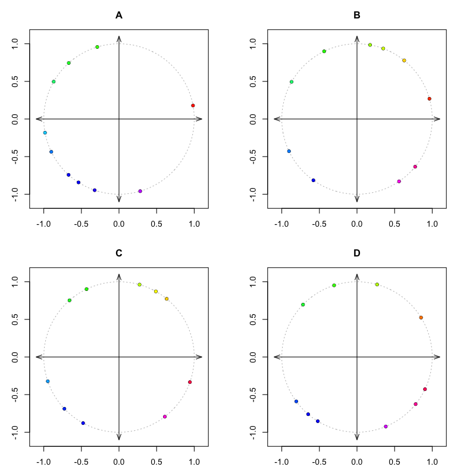

   - Plot matches the given list of angles.

   Now, in Desmos, you can type `(T,sin(T))` to get the points along the sine wave. Find the corresponding graph.

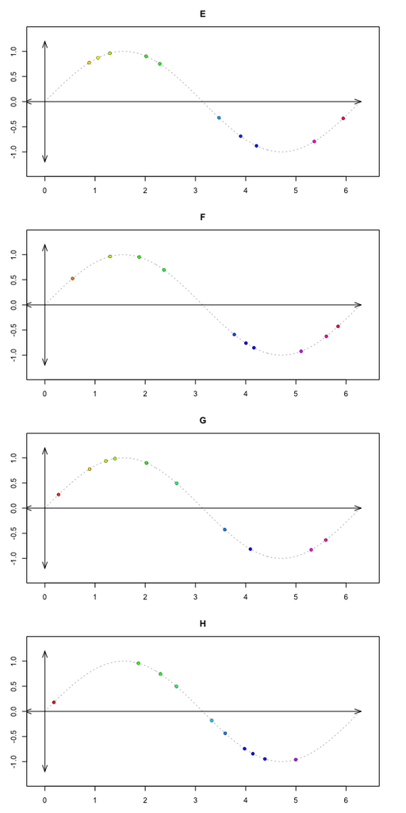

   - Plot matches the given list of angles.

   Lastly, in Desmos, you can type `(T,cos(T))` to get the points along the cosine wave. Find the corresponding graph.

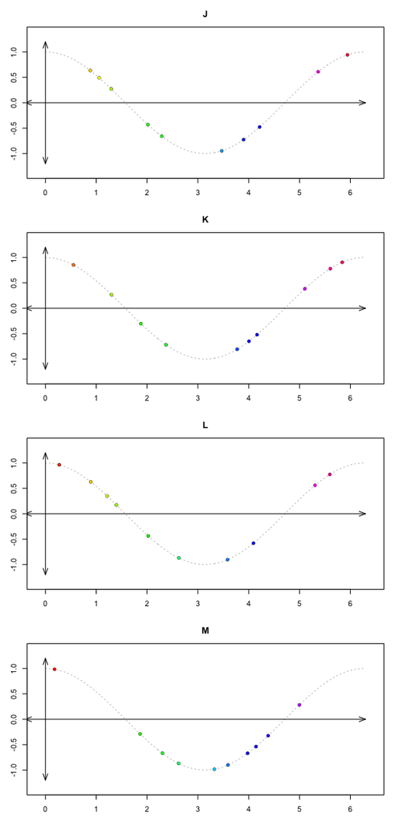